# Laboratorio 10-MD

Leislie R. Manjarrez O.

2023-02-22

Laboratorio 10- T1_04_REDES COMPLEJAS(1) - Vision de redes complejas - Parte 1

Objetivo: Estimar el Maximum Spanning Tree -arbol de expansion maxima- (asegurar una vision clara del espacio-producto) Red troncal: Estructura general de la red: vamos a poder ver redes complejas

Regla 1: mantener n-1 conexiones como maximo Regla 2: Quitar las conexiones con el peso mas bajo, nos vamos quedar con las del peso maximo (menos conexiones) Regla 3: No crear nodos aislados

En este ejercicio vamos a: 1. Usar un matriz hipotetica de datos 2. Graficar sus proximos adyacentes 1)La visualizacion del espacio - producto sea una red conectada: evitar islas de productos aislados. 2)PROBLEMA: tratar de visualizar demasiados enlaces puede crear una complejidad visual innecesaria donde se obstruiran las conexiones mas relevantes.

Calculamos el arbol de expansion maxima (MST) de la matriz de proximidad. MST es el conjunto de enlaces que conecta todos los nodos de la red utilizando un numero minimo de conexiones y la suma maxima posible de proximidades.

Calculamos el MST usando el algoritmo de Kruskal: Basicamente, el algoritmo clasifica los valores de la matriz de proximidad en orden descendente y luego incluye enlaces en el MST si y solo si conectan un producto aislado.

Por definicion, el MST incluye todos los productos, pero el numero de enlaces es el minimo posible.

Despues de seleccionar los enlaces utilizando los criterios mencionados anteriormente, construimos una visualizacion utilizando un algoritmo de dise?o dirigido por la fuerza.

Primero crear una matriz aleatoria de 200*200

```r
M <- matrix(runif(200*200, min=0, max=100), ncol=200)
diag(M)<-0
head (M[,1:6])
```

```
##          [,1]      [,2]     [,3]     [,4]     [,5]     [,6]
## [1,]  0.00000 65.794569 27.71712 62.38846 35.35130 14.20406
## [2,] 60.52021  0.000000 20.56530 36.74466 11.60647 43.99491
## [3,] 31.42418  1.151155  0.00000 51.50575 35.75350 10.86385
## [4,] 27.07134 38.355902 70.49268  0.00000 66.02831 95.53702
## [5,] 61.64912 94.128720 62.18586 30.47620  0.00000 15.46948
## [6,] 16.66076 88.291697 94.47953 50.24776 48.95470  0.00000
```

```r
dim (M)
```

```
## [1] 200 200
```

Llamar la libreria para graficar la matriz anterior

```r
library (igraph)
```

Comando para graficar la matriz anterior, obteniendo un grafico saturado por lo cual se usa el MST (igraph calcula el arbol de expansion minima)

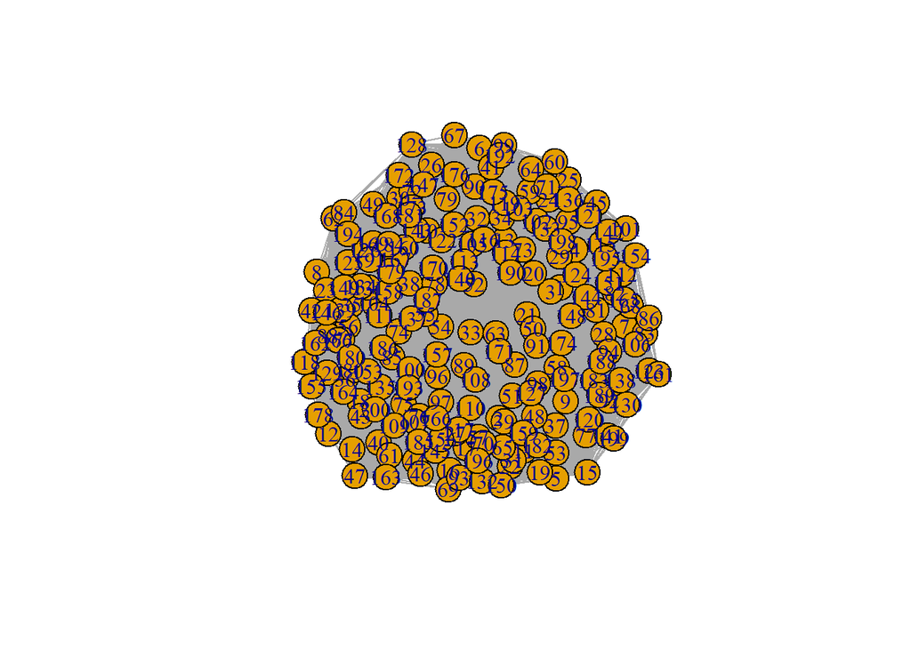

```r
g <- graph.adjacency(M, mode="undirected", weighted =TRUE)
plot (g)
```

Transformamos la matriz en NEGATIVA para identificar los maximos

```r
M <- -M
head (M[,1:6])
```

```
##           [,1]       [,2]      [,3]      [,4]      [,5]      [,6]
## [1,]   0.00000 -65.794569 -27.71712 -62.38846 -35.35130 -14.20406
## [2,] -60.52021   0.000000 -20.56530 -36.74466 -11.60647 -43.99491
## [3,] -31.42418  -1.151155   0.00000 -51.50575 -35.75350 -10.86385
## [4,] -27.07134 -38.355902 -70.49268   0.00000 -66.02831 -95.53702
## [5,] -61.64912 -94.128720 -62.18586 -30.47620   0.00000 -15.46948
## [6,] -16.66076 -88.291697 -94.47953 -50.24776 -48.95470   0.00000
```

Grafica nueva red con la matriz negativa, ver el espacio-producto, tecnologico

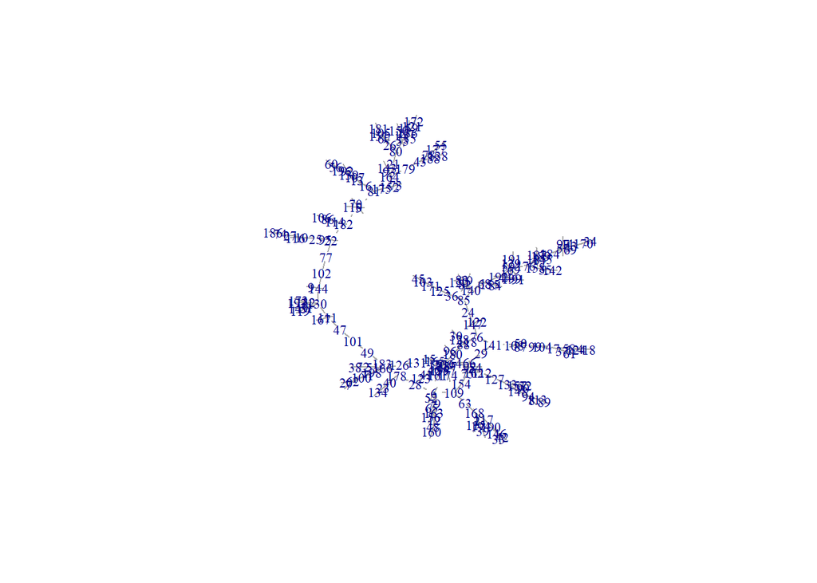

```r
g <- graph.adjacency(M, mode="undirected", weighted =TRUE)
MST <- minimum.spanning.tree(g)
plot(MST, vertex.shape="none", vertex.label.cex=.7)
```

Matriz de adyacencias (nuevo relacionamiento).Ver las aristas que hay entre los nodos

```r
A <- get.adjacency(MST, sparse = F)
```

```r
head(A)
```

```
##      [,1] [,2] [,3] [,4] [,5] [,6] [,7] [,8] [,9] [,10] [,11] [,12] [,13] [,14]
## [1,]    0    0    0    0    0    0    0    0    0     0     0     0     0     0
## [2,]    0    0    0    0    0    0    0    0    0     0     0     0     0     0
## [3,]    0    0    0    0    0    0    0    0    0     0     0     0     0     0
## [4,]    0    0    0    0    0    0    0    0    0     0     0     0     0     0
## [5,]    0    0    0    0    0    0    0    0    0     0     0     0     0     0
## [6,]    0    0    0    0    0    0    0    0    0     0     0     0     0     0
##      [,15] [,16] [,17] [,18] [,19] [,20] [,21] [,22] [,23] [,24] [,25] [,26]
## [1,]     0     0     0     0     0     0     0     0     0     0     0     0
## [2,]     0     0     0     0     0     0     0     0     0     0     0     0
## [3,]     0     0     0     0     0     0     0     0     0     0     0     0
## [4,]     0     0     0     1     0     0     0     0     0     0     0     0
## [5,]     0     0     0     0     0     0     0     0     0     0     0     0
## [6,]     0     0     0     0     0     0     0     0     0     0     0     0
##      [,27] [,28] [,29] [,30] [,31] [,32] [,33] [,34] [,35] [,36] [,37] [,38]
```

[output cut: 118 more lines]

Exportar el grafico en gml

```r
write.graph(MST, file = "g.gml", format = "gml")
```

Exportar resultados para cytoscape o gephi

```r
write.csv(A, file="Adyacentes.csv")
```